# Charlottesville Police, Temporary Detentions

# Introduction

A temporary detention involves a police officer holding and questioning an individual for a short amount of time. To detain someone, police only need a *reasonable suspicion* and detentions are often accompanied by some form of *search or frisk*.

We analyzed 865 temporary detentions made by the City of Charlottesville Police Department between 2012-2017. The data was received in response to Freedom of Information Act requests by Jeff Fogel made over multiple time periods. We found that the CPD detain an average of **15.4** individuals per month with **65% being search or frisked.** Significiantly, our analysis finds a disproportionate of detentions of black citizens compared to white citizens at a **2.3 rate**.

The following data demonstrates the CPD disproportionate detententions of black citizens:

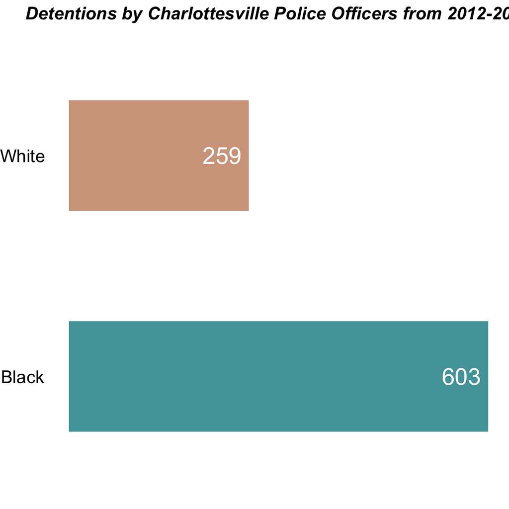

Even more telling is the percentage of CPD detentions of black citizens when compared to the black population of Charlottesville:

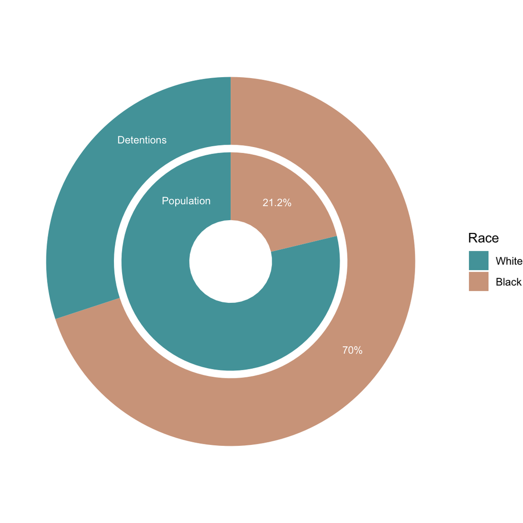

# Where?

### Where Do Police Detain People?

#### Map Details

- These maps display police detentions from both time periods, *2012-2014* and *2016-2017*.
- Each point represents one individual stopped.
- Points *do not* represent the exact locations of each stop, but the density of the dots represents the density of detainments in a [geographic area](https://opendata.charlottesville.org/datasets/police-neighborhood-area).
- To help guide your eyes, detentions that include Search and Frisk are circled in red.
- Turn on and off underlying population characteristics through the box on the right
- Note that the underlying population percentages are based on a comparison of White and Black populations only to align with the races identifiable in the police data files.

### Detentions 2012 - 2014 & 2016 - 2017

[interactive chart not shown]

### Detentions by Beat

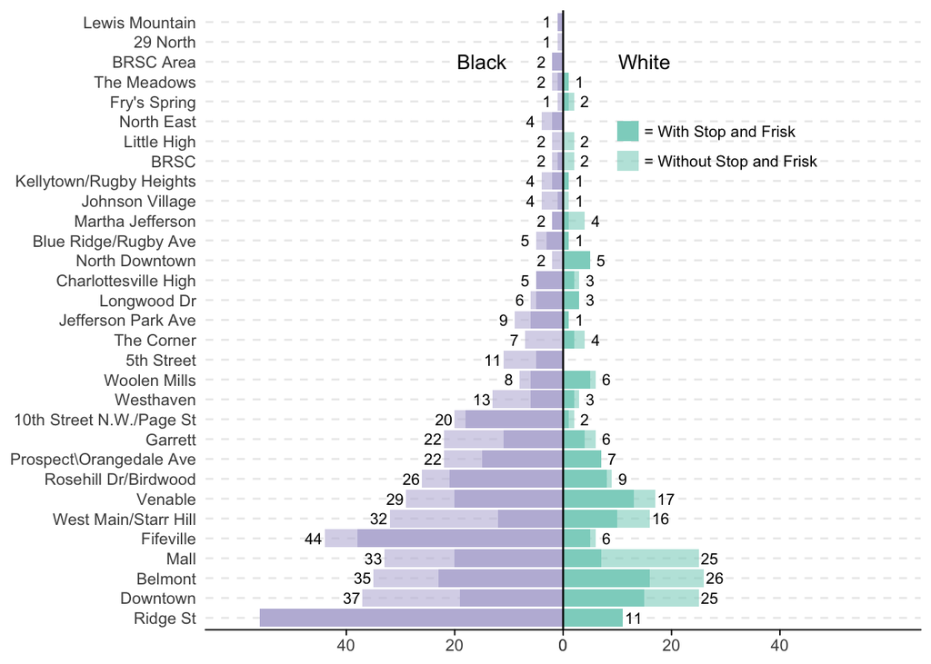

### Changes Over Time

Trends:

- Greater dispersion of stop and frisk throughout the city during the 2017
- Noticeable *decrease* of stop and frisk in the Rose Hill nieghborhood.
- Stop and frisk of black individuals in areas with predominantly student housing *increased*, specifically in the Grady, Rugby Road, and Emmet Street Areas in addition to the areas south of west main by the train tracks and Jefferson Park Avenue.
- Stop and Frisk *increased significantly*, particularly for black individuals, in the Prospect/Orangedale Ave area.

### 2012-2014

[interactive chart not shown]

### 2016-2017

[interactive chart not shown]

### Over Policing & Exclusive Spaces

The data does not record why police enter certain spaces, whether it is an officer-initiated discretionary stop or a response to a call. We also do not have data on whether or not a detainment led to an arrest. The offense listed is the reason the police officer recorded to justify the stop based on reasonable suspicion, not a determination that the offense occured. Beacuse of this, it is difficult to say that police detainments are an indicator of crime. Fewer detainments does not immediatley signify less crime in an area, just less police activity.

Below, we highlight three areas, a predominantly black residential space, a predominantly white residential space, and a public walking mall to investigate who police detain and where.

### Ridge Street & Prospect-Orangedale Neighborhoods

[interactive chart not shown]

### Martha Jefferson & Locust Grove Neighborhoods

[interactive chart not shown]

### Downtown

[interactive chart not shown]

```
## # A tibble: 9 x 8
## # Groups:   NAME, RACE [6]
##   NAME               BEAT_NO RACE  SFTYPE           Counts total RaceTot lab_pos
##   <chr>                <dbl> <fct> <chr>             <dbl> <int>   <dbl>   <dbl>
## 1 Martha Jefferson         8 Black STOP WITH SEARC…     -2     6      -2      -4
## 2 Martha Jefferson         8 White Search WITHOUT …      3     6       4       6
## 3 Martha Jefferson         8 White STOP WITH SEARC…      1     6       4       6
## 4 "Prospect\\Orange…      21 Black Search WITHOUT …     -7    29     -22     -24
## 5 "Prospect\\Orange…      21 Black STOP WITH SEARC…    -15    29     -22     -24
## 6 "Prospect\\Orange…      21 White STOP WITH SEARC…      7    29       7       9
## 7 Ridge St                12 Black Search WITHOUT …     -8    75     -64     -66
## 8 Ridge St                12 Black STOP WITH SEARC…    -56    75     -64     -66
## 9 Ridge St                12 White STOP WITH SEARC…     11    75      11      13
```

### Analysis

Historically, racial covenants prohibited Black individuals from living in the Martha Jefferson and Locust Grove. That legacy continues today

The Downtown Mall is a public space for free use by Charlottesville residents.